# Structured API Overview

In this lesson we will talk about Spark API overview (DataFrames, Datasets, RDD, and some operations)

Structured APIs are a tool for manipulating all kinds of data structured (Parquet files), unstructured(Log files) and semi-structured(CSV files)

## Summary

- 1. Context and Motivation
- 2. Dataframes and Datasets
  - 2.2. Columns
  - 2.3. Rows
  - 2.4. Spark Types
- 3. API Execution
  - 3.1. Logical Planning
  - 3.2. Physical Planning
  - 3.3. Execution
- 4. Structed Operations
  - 4.1. Columns and Expressions
  - 4.2. Records and Rows
- 5. Exercises
- 6. References

# 1. Context and Motivation

In order to do analysis with data we need structured the data and put the data in that structure.  
In this class we will deep dive in DataFrames, Datasets operations and Optimizations.

# 2. DataFrames and Datasets

There are three core types of distributed collection API's

- Datasets
- DataFrames
- SQL tables and views

Theses structured API's are the abstractions on we will write the the majority of data flows

Datasets and DataFrames are distributed table-like collections with well-defined rows and columns. Each column must have the same number of rows as all the other columns. Each column has a type information that is consistent for every row in the collection.

For Spark DataFrames and Datasets are immutable lazy evaluated plans the specify transformations/operations to apply to data to generate some output. When we call action, we instruct spark to do all the transformations/operations and return the result.

# What is the difference between DataFrames and Datasets?

**Dataframes** : Data is organized into named columns. For example a table in a relational database. It is an immutable distributed collection of data.It works only on structured and semi-structured data After transforming into DataFrame one cannot regenerate a domain object.It detects attribute error only at runtime.

**DataSets**: It is an extension of DataFrame API that provides the functionality of – type-safe, object-oriented.It also efficiently processes structured and unstructured data. It represents data in the form of JVM objects of row or a collection of row object. It provides compile-time type safety.

## 2.2. Columns

Columns represent a simple type like an integer or string, a complex type like an array or map, or a null value.

## 2.3. Rows

Row is a record of data

```python
spark.range(2).collect() # Creates two rows and print them.
```

```
[Row(id=0), Row(id=1)]
```

## 2.3. Spark Types

```python
from pyspark.sql.types import *
b = ByteType()
```

| Data Type | Value in Python | API to access or create a data type |
| --- | --- | --- |
| `ByteType` | int or long Ensure number within a range -128 to 127 | ByteType() |
| `ShortType` | int or long | ShortType() |
| `IntegerType` | int or long | IntegerType() |
| `LongType` | long | LongType() |
| `FloatType` | float | FloatType() |
| `DoubleType` | float | DoubleType() |
| `DecimalType` | decimal | DecimalType() |
| `StringType` | string | StringType() |
| `BinaryType` | bytearray | BinaryType() |
| `BooleanType` | decimal | BooleanType() |
| `TimeStampType` | datetime.datetime | TimeStampType() |
| `DateType` | datetime.date | DateType() |
| `ArrayType` | list, tuple, or array | ArrayType() |
| `MapType` | dict | MapType() |
| `StructType` | list or tuple | StructType() |
| `ArrayType` | list, tuple, or array | ArrayType() |
| `StructField` | list, tuple, or array | StructField(name, dataType, [nullable]) |

# 3. API Execution

In this section we will demonstrate how spark optimize queries.

We can either submit code to Spark either though the console or via submitted job.  
The code passes through the Catalyst Optimizer which decides how code will be executed and lays out a plan for doing so before. Finally, the code runs, and the result is returned to the user.

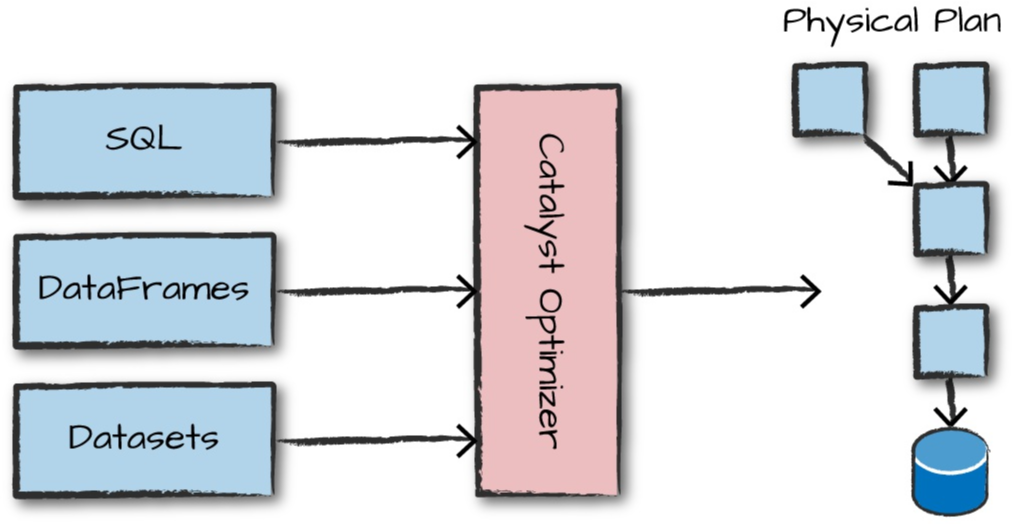

## 3.1. Logical Planning

Take our code and convert it into logical plan.

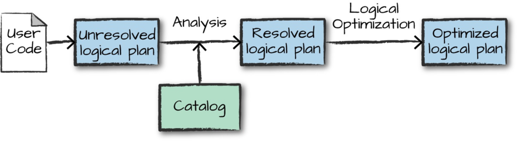

The logical plan represents a set of abstract transformations. It converts the user code into the most optimized version. The analyser may reject the logical plan if the required table or column name doesn't exist.  
If the Analyser can resolve it the result is passed through the Catalyst Optimizer which is a set of rules that attempt to optimize the logical plan.

## 3.2. Physical Planning

After successfully creating the optimized logical plan. Spark begins the physical planning process.  
This specifies how logical plan will execute on cluster by generating different physical execution strategies and comparing them through a cost model.

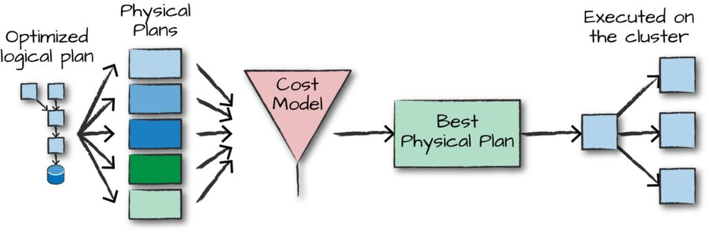

## 3.3. Execution

After selecting the physical plan to execute spark runs all of his this code over RDD (Resilient Distributed Datasets) the lower-level programming interface of spark.  
Spark performs further optimizations at runtime generate native java bytecode that can remove entire tasks or stages.

# 4. Structured Operations

In this chapter we will analyze and transform a retail dataset.

But first we need to put that in hadoop file system to do that:

- Open a new terminal
- Run `hdfs dfs -put retail_data_2010-12-01.csv`

```python
#Read the dataset
df = spark.read.format("csv")\
.option("header", "true")\
.option("inferSchema","true")\
.load("retail_data_2010-12-01.csv")
```

```python
df.printSchema()
```

```
root
 |-- InvoiceNo: string (nullable = true)
 |-- StockCode: string (nullable = true)
 |-- Description: string (nullable = true)
 |-- Quantity: integer (nullable = true)
 |-- InvoiceDate: timestamp (nullable = true)
 |-- UnitPrice: double (nullable = true)
 |-- CustomerID: double (nullable = true)
 |-- Country: string (nullable = true)
```

```python
df.show(5)
```

```
+---------+---------+--------------------+--------+-------------------+---------+----------+--------------+
|InvoiceNo|StockCode|         Description|Quantity|        InvoiceDate|UnitPrice|CustomerID|       Country|
+---------+---------+--------------------+--------+-------------------+---------+----------+--------------+
|   536365|   85123A|WHITE HANGING HEA...|       6|2010-12-01 08:26:00|     2.55|   17850.0|United Kingdom|
|   536365|    71053| WHITE METAL LANTERN|       6|2010-12-01 08:26:00|     3.39|   17850.0|United Kingdom|
|   536365|   84406B|CREAM CUPID HEART...|       8|2010-12-01 08:26:00|     2.75|   17850.0|United Kingdom|
|   536365|   84029G|KNITTED UNION FLA...|       6|2010-12-01 08:26:00|     3.39|   17850.0|United Kingdom|
|   536365|   84029E|RED WOOLLY HOTTIE...|       6|2010-12-01 08:26:00|     3.39|   17850.0|United Kingdom|
+---------+---------+--------------------+--------+-------------------+---------+----------+--------------+
only showing top 5 rows
```

## 4.1. Columns and Expressions

What is the shema? Use printSchema() function to see the schema.

**We can define schema manual as this:**

```python
from pyspark.sql.types import StructField, StructType, StringType, IntegerType, TimestampType, DoubleType

manualSchema = StructType([StructField("InvoiceNo", StringType(),True),
                             StructField("StockCode", StringType(),True),
                             StructField("Description", StringType(),True),
                             StructField("Quantity", IntegerType(),True),
                             StructField("InvoiceDate", TimestampType(),True),
                             StructField("UnitPrice", DoubleType(),True),
                             StructField("CustomerID", DoubleType(),True),
                             StructField("Country", StringType(),True)
                            ])
```

```python
df = spark.read.format("csv").schema(manualSchema).load("retail_data_2010-12-01.csv")
```

```python
# Columns are similar to coluns in pandas dataframes
# we can manipulate or remove columns  using expression operations
# In spark we can't manipulate individual columns outside the context of dataframes
# We must use Spark transformations to modify the content of a column

# to create a column use

from pyspark.sql.functions import col, column
# Works the same there is no difference see
col("newColumnName")
column("newColumnName")
```

```
Column<b'newColumnName'>
```

```python
(((col("someCol") + 5) * 200) -6) < col("otherCol")
```

```
Column<b'((((someCol + 5) * 200) - 6) < otherCol)'>
```

```python
from pyspark.sql.functions import expr
expr("(((someCol + 5)* 200) -6 ) < otherCol")
```

```
Column<b'((((someCol + 5) * 200) - 6) < otherCol)'>
```

## 4.2. Records and Rows

```python
df.first()
```

```
Row(InvoiceNo=None, StockCode=None, Description=None, Quantity=None, InvoiceDate=None, UnitPrice=None, CustomerID=None, Country=None)
```

### Creating Rows

```python
from pyspark.sql import Row
newRow = Row("555555","85123B","New Product",2016,6,2.1,141131,"Lisbon")
```

### Create Dataframe

```python
# This code will create a new row and assign the columns name numbers like _1, _2 etc..
# To specify the column name, we need to define the schema
myDataframe = spark.createDataFrame([newRow])
```

```python
myDataframe.take(1)
```

```
[Row(_1='555555', _2='85123B', _3='New Product', _4=2016, _5=6, _6=2.1, _7=141131, _8='Lisbon')]
```

### Select and SelectExpr

These functions allow to do the DataFrame equivalent of SQL queries on a table of data.

- `Select` and `SelectExpt` are the same only with different definitions.

```python
df.select("Description","Country").show(50);
```

```
+--------------------+--------------+
|         Description|       Country|
+--------------------+--------------+
|         Description|       Country|
|WHITE HANGING HEA...|United Kingdom|
| WHITE METAL LANTERN|United Kingdom|
|CREAM CUPID HEART...|United Kingdom|
|KNITTED UNION FLA...|United Kingdom|
|RED WOOLLY HOTTIE...|United Kingdom|
|SET 7 BABUSHKA NE...|United Kingdom|
|GLASS STAR FROSTE...|United Kingdom|
|HAND WARMER UNION...|United Kingdom|
|HAND WARMER RED P...|United Kingdom|
|ASSORTED COLOUR B...|United Kingdom|
|POPPY'S PLAYHOUSE...|United Kingdom|
|POPPY'S PLAYHOUSE...|United Kingdom|
|FELTCRAFT PRINCES...|United Kingdom|
|IVORY KNITTED MUG...|United Kingdom|
|BOX OF 6 ASSORTED...|United Kingdom|
|BOX OF VINTAGE JI...|United Kingdom|
|BOX OF VINTAGE AL...|United Kingdom|
|HOME BUILDING BLO...|United Kingdom|
|LOVE BUILDING BLO...|United Kingdom|
|RECIPE BOX WITH M...|United Kingdom|
| DOORMAT NEW ENGLAND|United Kingdom|
|JAM MAKING SET WI...|United Kingdom|
|RED COAT RACK PAR...|United Kingdom|
|YELLOW COAT RACK ...|United Kingdom|
|BLUE COAT RACK PA...|United Kingdom|
|BATH BUILDING BLO...|United Kingdom|
|ALARM CLOCK BAKEL...|        France|
|ALARM CLOCK BAKEL...|        France|
|ALARM CLOCK BAKEL...|        France|
|PANDA AND BUNNIES...|        France|
|    STARS GIFT TAPE |        France|
|INFLATABLE POLITI...|        France|
|VINTAGE HEADS AND...|        France|
|SET/2 RED RETROSP...|        France|
|ROUND SNACK BOXES...|        France|
| SPACEBOY LUNCH BOX |        France|
|LUNCH BOX I LOVE ...|        France|
|CIRCUS PARADE LUN...|        France|
|CHARLOTTE BAG DOL...|        France|
|RED TOADSTOOL LED...|        France|
| SET 2 TEA TOWELS...|        France|
|VINTAGE SEASIDE J...|        France|
|MINI JIGSAW CIRCU...|        France|
|MINI JIGSAW SPACEBOY|        France|
|MINI PAINT SET VI...|        France|
|             POSTAGE|        France|
|PAPER CHAIN KIT 5...|United Kingdom|
|HAND WARMER RED P...|United Kingdom|
|HAND WARMER UNION...|United Kingdom|
+--------------------+--------------+
only showing top 50 rows
```

### Adding explicit values to compare (Literals)

```python
from pyspark.sql.functions import lit
df.select(expr("*"), lit("Portugal").alias("Other")).show(2)
```

```
+---------+---------+--------------------+--------+-------------------+---------+----------+--------------+--------+
|InvoiceNo|StockCode|         Description|Quantity|        InvoiceDate|UnitPrice|CustomerID|       Country|   Other|
+---------+---------+--------------------+--------+-------------------+---------+----------+--------------+--------+
|     null|     null|                null|    null|               null|     null|      null|          null|Portugal|
|   536365|   85123A|WHITE HANGING HEA...|       6|2010-12-01 08:26:00|     2.55|   17850.0|United Kingdom|Portugal|
+---------+---------+--------------------+--------+-------------------+---------+----------+--------------+--------+
only showing top 2 rows
```

```python
df.show(2)
```

```
+---------+---------+--------------------+--------+-------------------+---------+----------+--------------+
|InvoiceNo|StockCode|         Description|Quantity|        InvoiceDate|UnitPrice|CustomerID|       Country|
+---------+---------+--------------------+--------+-------------------+---------+----------+--------------+
|     null|     null|                null|    null|               null|     null|      null|          null|
|   536365|   85123A|WHITE HANGING HEA...|       6|2010-12-01 08:26:00|     2.55|   17850.0|United Kingdom|
+---------+---------+--------------------+--------+-------------------+---------+----------+--------------+
only showing top 2 rows
```

### Adding Columns to Dataframe

```python
df_new_column = df.withColumn("OtherC", lit("Portugal"))
```

```python
df_new_column.withColumn("OtherC", expr("Country")).show(5)
```

```
+---------+---------+--------------------+--------+-------------------+---------+----------+--------------+--------------+
|InvoiceNo|StockCode|         Description|Quantity|        InvoiceDate|UnitPrice|CustomerID|       Country|        OtherC|
+---------+---------+--------------------+--------+-------------------+---------+----------+--------------+--------------+
|     null|     null|                null|    null|               null|     null|      null|          null|          null|
|   536365|   85123A|WHITE HANGING HEA...|       6|2010-12-01 08:26:00|     2.55|   17850.0|United Kingdom|United Kingdom|
|   536365|    71053| WHITE METAL LANTERN|       6|2010-12-01 08:26:00|     3.39|   17850.0|United Kingdom|United Kingdom|
|   536365|   84406B|CREAM CUPID HEART...|       8|2010-12-01 08:26:00|     2.75|   17850.0|United Kingdom|United Kingdom|
|   536365|   84029G|KNITTED UNION FLA...|       6|2010-12-01 08:26:00|     3.39|   17850.0|United Kingdom|United Kingdom|
+---------+---------+--------------------+--------+-------------------+---------+----------+--------------+--------------+
only showing top 5 rows
```

```python
# Check if the country has the same value of OtherCountry
df_new_column.withColumn("withinCounty", expr("Country == OtherC")).show(5)
```

```
+---------+---------+--------------------+--------+-------------------+---------+----------+--------------+--------+------------+
|InvoiceNo|StockCode|         Description|Quantity|        InvoiceDate|UnitPrice|CustomerID|       Country|  OtherC|withinCounty|
+---------+---------+--------------------+--------+-------------------+---------+----------+--------------+--------+------------+
|     null|     null|                null|    null|               null|     null|      null|          null|Portugal|        null|
|   536365|   85123A|WHITE HANGING HEA...|       6|2010-12-01 08:26:00|     2.55|   17850.0|United Kingdom|Portugal|       false|
|   536365|    71053| WHITE METAL LANTERN|       6|2010-12-01 08:26:00|     3.39|   17850.0|United Kingdom|Portugal|       false|
|   536365|   84406B|CREAM CUPID HEART...|       8|2010-12-01 08:26:00|     2.75|   17850.0|United Kingdom|Portugal|       false|
|   536365|   84029G|KNITTED UNION FLA...|       6|2010-12-01 08:26:00|     3.39|   17850.0|United Kingdom|Portugal|       false|
+---------+---------+--------------------+--------+-------------------+---------+----------+--------------+--------+------------+
only showing top 5 rows
```

### Rename Columns

```python
# Use the function withColumnRenamed
df_with_renamed_column = df.withColumnRenamed("Country", "OriginCounty")
```

```python
df_with_renamed_column
```

```
DataFrame[InvoiceNo: string, StockCode: string, Description: string, Quantity: int, InvoiceDate: timestamp, UnitPrice: double, CustomerID: double, OriginCounty: string]
```

### Remove Columns

```python
new_df = df_with_renamed_column.drop("OriginCounty")
```

```python
new_df.show(5)
```

```
+---------+---------+--------------------+--------+-------------------+---------+----------+
|InvoiceNo|StockCode|         Description|Quantity|        InvoiceDate|UnitPrice|CustomerID|
+---------+---------+--------------------+--------+-------------------+---------+----------+
|     null|     null|                null|    null|               null|     null|      null|
|   536365|   85123A|WHITE HANGING HEA...|       6|2010-12-01 08:26:00|     2.55|   17850.0|
|   536365|    71053| WHITE METAL LANTERN|       6|2010-12-01 08:26:00|     3.39|   17850.0|
|   536365|   84406B|CREAM CUPID HEART...|       8|2010-12-01 08:26:00|     2.75|   17850.0|
|   536365|   84029G|KNITTED UNION FLA...|       6|2010-12-01 08:26:00|     3.39|   17850.0|
+---------+---------+--------------------+--------+-------------------+---------+----------+
only showing top 5 rows
```

### Remove Multiple Columns

```python
new_df = df_with_renamed_column.drop("OriginCounty","UnitPrice")
```

```python
new_df.show(5)
```

```
+---------+---------+--------------------+--------+-------------------+----------+
|InvoiceNo|StockCode|         Description|Quantity|        InvoiceDate|CustomerID|
+---------+---------+--------------------+--------+-------------------+----------+
|     null|     null|                null|    null|               null|      null|
|   536365|   85123A|WHITE HANGING HEA...|       6|2010-12-01 08:26:00|   17850.0|
|   536365|    71053| WHITE METAL LANTERN|       6|2010-12-01 08:26:00|   17850.0|
|   536365|   84406B|CREAM CUPID HEART...|       8|2010-12-01 08:26:00|   17850.0|
|   536365|   84029G|KNITTED UNION FLA...|       6|2010-12-01 08:26:00|   17850.0|
+---------+---------+--------------------+--------+-------------------+----------+
only showing top 5 rows
```

### Changing a column type

```python
df_with_newcoltype = df.withColumn("Quantity2",col("Quantity").cast("string"))
```

```python
df_with_newcoltype.show(2)
df_with_newcoltype.printSchema()
```

```
+---------+---------+--------------------+--------+-------------------+---------+----------+--------------+---------+
|InvoiceNo|StockCode|         Description|Quantity|        InvoiceDate|UnitPrice|CustomerID|       Country|Quantity2|
+---------+---------+--------------------+--------+-------------------+---------+----------+--------------+---------+
|     null|     null|                null|    null|               null|     null|      null|          null|     null|
|   536365|   85123A|WHITE HANGING HEA...|       6|2010-12-01 08:26:00|     2.55|   17850.0|United Kingdom|        6|
+---------+---------+--------------------+--------+-------------------+---------+----------+--------------+---------+
only showing top 2 rows

root
 |-- InvoiceNo: string (nullable = true)
 |-- StockCode: string (nullable = true)
 |-- Description: string (nullable = true)
 |-- Quantity: integer (nullable = true)
 |-- InvoiceDate: timestamp (nullable = true)
 |-- UnitPrice: double (nullable = true)
 |-- CustomerID: double (nullable = true)
 |-- Country: string (nullable = true)
 |-- Quantity2: string (nullable = true)
```

### Filtering Rows

To filter rows, we can create an expression that evaluates to true or false then we filter with an expression.  
For that we can use `filter` or `where`.

```python
df.filter(col("Quantity") < 5).show(2)
```

```
+---------+---------+--------------------+--------+-------------------+---------+----------+--------------+
|InvoiceNo|StockCode|         Description|Quantity|        InvoiceDate|UnitPrice|CustomerID|       Country|
+---------+---------+--------------------+--------+-------------------+---------+----------+--------------+
|   536365|    22752|SET 7 BABUSHKA NE...|       2|2010-12-01 08:26:00|     7.65|   17850.0|United Kingdom|
|   536367|    22623|BOX OF VINTAGE JI...|       3|2010-12-01 08:34:00|     4.95|   13047.0|United Kingdom|
+---------+---------+--------------------+--------+-------------------+---------+----------+--------------+
only showing top 2 rows
```

```python
df.where(col("Quantity") < 5).show(2)
```

```
+---------+---------+--------------------+--------+-------------------+---------+----------+--------------+
|InvoiceNo|StockCode|         Description|Quantity|        InvoiceDate|UnitPrice|CustomerID|       Country|
+---------+---------+--------------------+--------+-------------------+---------+----------+--------------+
|   536365|    22752|SET 7 BABUSHKA NE...|       2|2010-12-01 08:26:00|     7.65|   17850.0|United Kingdom|
|   536367|    22623|BOX OF VINTAGE JI...|       3|2010-12-01 08:34:00|     4.95|   13047.0|United Kingdom|
+---------+---------+--------------------+--------+-------------------+---------+----------+--------------+
only showing top 2 rows
```

### Getting Unique rows

Using the **dataset** use the **distinct to count** the number of unique column Country that appears in the dataset.  
**Tip:** Use the function `distinct()` and `count()`.

```python
# Use distinct to count the distinct Country that appears in the dataset
df.select("Country").distinct().count()
```

```
8
```

```python
df.select(col("Country")).distinct().count()
```

```
8
```

### Random Sample

Sometimes for training a model we need to get a random sample of our data to do that we use the function `df.sample()`

```python
df.count()
```

```
3109
```

```python
seed = 5
with_replacement = False
fraction = 0.5
df.sample(withReplacement=with_replacement, fraction=fraction, seed=seed).count()# reduce to 50%
```

```
1549
```

### Random Splits

Random Splits can be help full when we need to break our dataset into random splits of the original.  
This is often used in machine learning algorithms to create training validation and test sets.

```python
dataframes = df.randomSplit([0.25, 0.75])
dataframes[0].count() > dataframes[1].count()
```

```
False
```

```python
dataframes[0].count()
```

```
787
```

```python
dataframes[1].count()
```

```
2322
```

### Concatenating and Appending Rows

To union two DataFrames **we must make sure that they have the same schema and number of columns.**

```python
schema = df.schema

newRows = [Row("555555","85123B","New Product",2016,6,2.1,141131,"Lisbon"),
          Row("555556","85124B","New Product2 ",2017,7,2.1,141131,"Lisbon")]
parallelizedRows = spark.sparkContext.parallelize(newRow)
newDF = spark.createDataFrame(parallelizedRows,schema)
```

### Sorting Rows

Sometimes we need to sort our values by newer data, biggest value etc... to do that we use:

- `sort` or `orderBy` it works exactly at the same way
- For **Optimization** sometimes it's advisable to sort with partitions before any transformation. We can use `sortWithinPartitions` for the effect

```python
df.orderBy(col("Quantity")).show(5)
df.orderBy("Quantity").show(5)
df.sort("Quantity").show(5)
```

```
+---------+---------+--------------------+--------+-------------------+---------+----------+--------------+
|InvoiceNo|StockCode|         Description|Quantity|        InvoiceDate|UnitPrice|CustomerID|       Country|
+---------+---------+--------------------+--------+-------------------+---------+----------+--------------+
|     null|     null|                null|    null|               null|     null|      null|          null|
|  C536391|    21983|PACK OF 12 BLUE P...|     -24|2010-12-01 10:24:00|     0.29|   17548.0|United Kingdom|
|  C536391|    21980|PACK OF 12 RED RE...|     -24|2010-12-01 10:24:00|     0.29|   17548.0|United Kingdom|
|  C536391|    22553|PLASTERS IN TIN S...|     -24|2010-12-01 10:24:00|     1.65|   17548.0|United Kingdom|
|  C536391|    21984|PACK OF 12 PINK P...|     -24|2010-12-01 10:24:00|     0.29|   17548.0|United Kingdom|
+---------+---------+--------------------+--------+-------------------+---------+----------+--------------+
only showing top 5 rows

+---------+---------+--------------------+--------+-------------------+---------+----------+--------------+
|InvoiceNo|StockCode|         Description|Quantity|        InvoiceDate|UnitPrice|CustomerID|       Country|
+---------+---------+--------------------+--------+-------------------+---------+----------+--------------+
|     null|     null|                null|    null|               null|     null|      null|          null|
|  C536391|    21983|PACK OF 12 BLUE P...|     -24|2010-12-01 10:24:00|     0.29|   17548.0|United Kingdom|
|  C536391|    21980|PACK OF 12 RED RE...|     -24|2010-12-01 10:24:00|     0.29|   17548.0|United Kingdom|
|  C536391|    22553|PLASTERS IN TIN S...|     -24|2010-12-01 10:24:00|     1.65|   17548.0|United Kingdom|
|  C536391|    21984|PACK OF 12 PINK P...|     -24|2010-12-01 10:24:00|     0.29|   17548.0|United Kingdom|
+---------+---------+--------------------+--------+-------------------+---------+----------+--------------+
only showing top 5 rows

+---------+---------+--------------------+--------+-------------------+---------+----------+--------------+
|InvoiceNo|StockCode|         Description|Quantity|        InvoiceDate|UnitPrice|CustomerID|       Country|
+---------+---------+--------------------+--------+-------------------+---------+----------+--------------+
|     null|     null|                null|    null|               null|     null|      null|          null|
|  C536391|    21983|PACK OF 12 BLUE P...|     -24|2010-12-01 10:24:00|     0.29|   17548.0|United Kingdom|
|  C536391|    21980|PACK OF 12 RED RE...|     -24|2010-12-01 10:24:00|     0.29|   17548.0|United Kingdom|
|  C536391|    22553|PLASTERS IN TIN S...|     -24|2010-12-01 10:24:00|     1.65|   17548.0|United Kingdom|
|  C536391|    21984|PACK OF 12 PINK P...|     -24|2010-12-01 10:24:00|     0.29|   17548.0|United Kingdom|
+---------+---------+--------------------+--------+-------------------+---------+----------+--------------+
only showing top 5 rows
```

To specify the direction, we must use the keywords

- `desc` -> Orders data from the biggest value to the lower.
- `asc` -> Orders the data from the lower value to the biggest.

**Exercise**

Using the functions desc and asc:

- Order the dataframe by UnitPrice order ascending.
- Order the dataframe by Quantity order descending.

```python
from pyspark.sql.functions import desc, asc
```

```python
# Order the dataframe by UnitPrice order ascending.
df.orderBy(expr("UnitPrice asc")).show(2)
df.orderBy(col("UnitPrice").asc()).show(2)
```

```
+---------+---------+-----------+--------+-------------------+---------+----------+--------------+
|InvoiceNo|StockCode|Description|Quantity|        InvoiceDate|UnitPrice|CustomerID|       Country|
+---------+---------+-----------+--------+-------------------+---------+----------+--------------+
|     null|     null|       null|    null|               null|     null|      null|          null|
|   536546|    22145|       null|       1|2010-12-01 14:33:00|      0.0|      null|United Kingdom|
+---------+---------+-----------+--------+-------------------+---------+----------+--------------+
only showing top 2 rows

+---------+---------+-----------+--------+-------------------+---------+----------+--------------+
|InvoiceNo|StockCode|Description|Quantity|        InvoiceDate|UnitPrice|CustomerID|       Country|
+---------+---------+-----------+--------+-------------------+---------+----------+--------------+
|     null|     null|       null|    null|               null|     null|      null|          null|
|   536546|    22145|       null|       1|2010-12-01 14:33:00|      0.0|      null|United Kingdom|
+---------+---------+-----------+--------+-------------------+---------+----------+--------------+
only showing top 2 rows
```

```python
# Order the dataframe by Quantity order descending.
df.orderBy(expr("Quantity desc")).show(5)
df.orderBy(col("Quantity").desc()).show(5)
```

```
+---------+---------+--------------------+--------+-------------------+---------+----------+--------------+
|InvoiceNo|StockCode|         Description|Quantity|        InvoiceDate|UnitPrice|CustomerID|       Country|
+---------+---------+--------------------+--------+-------------------+---------+----------+--------------+
|     null|     null|                null|    null|               null|     null|      null|          null|
|  C536391|    21983|PACK OF 12 BLUE P...|     -24|2010-12-01 10:24:00|     0.29|   17548.0|United Kingdom|
|  C536391|    21980|PACK OF 12 RED RE...|     -24|2010-12-01 10:24:00|     0.29|   17548.0|United Kingdom|
|  C536391|    22553|PLASTERS IN TIN S...|     -24|2010-12-01 10:24:00|     1.65|   17548.0|United Kingdom|
|  C536391|    21984|PACK OF 12 PINK P...|     -24|2010-12-01 10:24:00|     0.29|   17548.0|United Kingdom|
+---------+---------+--------------------+--------+-------------------+---------+----------+--------------+
only showing top 5 rows

+---------+---------+--------------------+--------+-------------------+---------+----------+--------------+
|InvoiceNo|StockCode|         Description|Quantity|        InvoiceDate|UnitPrice|CustomerID|       Country|
+---------+---------+--------------------+--------+-------------------+---------+----------+--------------+
|   536437|    17021|NAMASTE SWAGAT IN...|     600|2010-12-01 12:12:00|     0.24|   13694.0|United Kingdom|
|   536477|    21137|BLACK RECORD COVE...|     480|2010-12-01 12:27:00|     3.39|   16210.0|United Kingdom|
|   536387|    22466|FAIRY TALE COTTAG...|     432|2010-12-01 09:58:00|     1.45|   16029.0|United Kingdom|
|   536387|    21731|RED TOADSTOOL LED...|     432|2010-12-01 09:58:00|     1.25|   16029.0|United Kingdom|
|   536584|   84029E|RED WOOLLY HOTTIE...|     384|2010-12-01 16:22:00|     2.95|   13777.0|United Kingdom|
+---------+---------+--------------------+--------+-------------------+---------+----------+--------------+
only showing top 5 rows
```

```python
df.orderBy(expr("Quantity desc")).explain() # show the differences between expr <Colname desc>
df.orderBy(col("Quantity").desc()).explain()# show the differences between <Colname>.desc()
```

```
== Physical Plan ==
*(2) Sort [Quantity#64 ASC NULLS FIRST], true, 0
+- Exchange rangepartitioning(Quantity#64 ASC NULLS FIRST, 200)
   +- *(1) FileScan csv [InvoiceNo#61,StockCode#62,Description#63,Quantity#64,InvoiceDate#65,UnitPrice#66,CustomerID#67,Country#68] Batched: false, Format: CSV, Location: InMemoryFileIndex[file:/Users/hugosantos/Dropbox/BigData1920/Práticas/Aula 4 - Structed API Over..., PartitionFilters: [], Pushed…
== Physical Plan ==
*(2) Sort [Quantity#64 DESC NULLS LAST], true, 0
+- Exchange rangepartitioning(Quantity#64 DESC NULLS LAST, 200)
   +- *(1) FileScan csv [InvoiceNo#61,StockCode#62,Description#63,Quantity#64,InvoiceDate#65,UnitPrice#66,CustomerID#67,Country#68] Batched: false, Format: CSV, Location: InMemoryFileIndex[file:/Users/hugosantos/Dropbox/BigData1920/Práticas/Aula 4 - Structed API Over..., PartitionFilters: [], Pushed…
```

```python
# Order the dataframe by Quantity descending and UnitPrice ascending
df.orderBy(col("Quantity").desc(), col("UnitPrice").asc()).show()
```

```
+---------+---------+--------------------+--------+-------------------+---------+----------+--------------+
|InvoiceNo|StockCode|         Description|Quantity|        InvoiceDate|UnitPrice|CustomerID|       Country|
+---------+---------+--------------------+--------+-------------------+---------+----------+--------------+
|   536437|    17021|NAMASTE SWAGAT IN...|     600|2010-12-01 12:12:00|     0.24|   13694.0|United Kingdom|
|   536477|    21137|BLACK RECORD COVE...|     480|2010-12-01 12:27:00|     3.39|   16210.0|United Kingdom|
|   536387|    21731|RED TOADSTOOL LED...|     432|2010-12-01 09:58:00|     1.25|   16029.0|United Kingdom|
|   536387|    22466|FAIRY TALE COTTAG...|     432|2010-12-01 09:58:00|     1.45|   16029.0|United Kingdom|
|   536584|   84029E|RED WOOLLY HOTTIE...|     384|2010-12-01 16:22:00|     2.95|   13777.0|United Kingdom|
|   536390|    20668|DISCO BALL CHRIST...|     288|2010-12-01 10:19:00|      0.1|   17511.0|United Kingdom|
|   536575|    22095|LADS ONLY TISSUE BOX|     252|2010-12-01 16:01:00|     1.25|   13777.0|United Kingdom|
|   536579|    21232|STRAWBERRY CERAMI...|     216|2010-12-01 16:16:00|     1.06|   13777.0|United Kingdom|
|   536437|    21154|RED RETROSPOT OVE...|     200|2010-12-01 12:12:00|     1.06|   13694.0|United Kingdom|
|   536581|   85099B|JUMBO BAG RED RET...|     200|2010-12-01 16:19:00|     1.65|   13777.0|United Kingdom|
|   536387|    22779|WOODEN OWLS LIGHT...|     192|2010-12-01 09:58:00|     3.37|   16029.0|United Kingdom|
|   536387|    22780|LIGHT GARLAND BUT...|     192|2010-12-01 09:58:00|     3.37|   16029.0|United Kingdom|
|   536387|    79321|       CHILLI LIGHTS|     192|2010-12-01 09:58:00|     3.82|   16029.0|United Kingdom|
|   536390|    21786|  POLKADOT RAIN HAT |     144|2010-12-01 10:19:00|     0.32|   17511.0|United Kingdom|
|   536508|    21326|AGED GLASS SILVER...|     144|2010-12-01 12:38:00|     0.55|   17181.0|United Kingdom|
|   536390|   84970S|HANGING HEART ZIN...|     144|2010-12-01 10:19:00|     0.64|   17511.0|United Kingdom|
|   536477|    22593|CHRISTMAS GINGHAM...|     144|2010-12-01 12:27:00|     0.72|   16210.0|United Kingdom|
|   536477|    22595|CHRISTMAS GINGHAM...|     144|2010-12-01 12:27:00|     0.72|   16210.0|United Kingdom|
|   536576|    20971|PINK BLUE FELT CR...|     144|2010-12-01 16:11:00|     1.06|   13777.0|United Kingdom|
|   536575|    21232|STRAWBERRY CERAMI...|     144|2010-12-01 16:01:00|     1.25|   13777.0|United Kingdom|
+---------+---------+--------------------+--------+-------------------+---------+----------+--------------+
only showing top 20 rows
```

### Limit

Limit the number of rows to show in the output. Like Limit function in SQL.  
More performant than **show()**.

```python
df.limit(5).show()
```

```
+---------+---------+--------------------+--------+-------------------+---------+----------+--------------+
|InvoiceNo|StockCode|         Description|Quantity|        InvoiceDate|UnitPrice|CustomerID|       Country|
+---------+---------+--------------------+--------+-------------------+---------+----------+--------------+
|     null|     null|                null|    null|               null|     null|      null|          null|
|   536365|   85123A|WHITE HANGING HEA...|       6|2010-12-01 08:26:00|     2.55|   17850.0|United Kingdom|
|   536365|    71053| WHITE METAL LANTERN|       6|2010-12-01 08:26:00|     3.39|   17850.0|United Kingdom|
|   536365|   84406B|CREAM CUPID HEART...|       8|2010-12-01 08:26:00|     2.75|   17850.0|United Kingdom|
|   536365|   84029G|KNITTED UNION FLA...|       6|2010-12-01 08:26:00|     3.39|   17850.0|United Kingdom|
+---------+---------+--------------------+--------+-------------------+---------+----------+--------------+
```

```python
df.orderBy(expr("Quantity desc")).limit(5).show()
```

```
+---------+---------+--------------------+--------+-------------------+---------+----------+--------------+
|InvoiceNo|StockCode|         Description|Quantity|        InvoiceDate|UnitPrice|CustomerID|       Country|
+---------+---------+--------------------+--------+-------------------+---------+----------+--------------+
|     null|     null|                null|    null|               null|     null|      null|          null|
|  C536391|    21983|PACK OF 12 BLUE P...|     -24|2010-12-01 10:24:00|     0.29|   17548.0|United Kingdom|
|  C536391|    21984|PACK OF 12 PINK P...|     -24|2010-12-01 10:24:00|     0.29|   17548.0|United Kingdom|
|  C536391|    22553|PLASTERS IN TIN S...|     -24|2010-12-01 10:24:00|     1.65|   17548.0|United Kingdom|
|  C536391|    21980|PACK OF 12 RED RE...|     -24|2010-12-01 10:24:00|     0.29|   17548.0|United Kingdom|
+---------+---------+--------------------+--------+-------------------+---------+----------+--------------+
```

### Repartition and Coalesce

Optimization opportunity is to partition the data according to some frequently filtered columns, which control the physical layout of data across the cluster including the partitioning scheme and the number of partitions.  
Repartition will incur a full shuffle of the data.

`getNumPartitions` -> Get the number of partitions of actual DataFrame.  
`repartition` -> Repartition the dataset.  
`Coalesce` -> The coalesce method reduces the number of partitions in a DataFrame. This operation will shuffle your data into five partitions based on the country, and then coalesce them.

```python
df.rdd.getNumPartitions()
```

```
1
```

```python
df.repartition(5) # repatition the DataFrame in 5 partitions
```

```
DataFrame[InvoiceNo: string, StockCode: string, Description: string, Quantity: int, InvoiceDate: timestamp, UnitPrice: double, CustomerID: double, Country: string]
```

```python
df.repartition(col("Country")) # repatition the DataFrame by Country column.
```

```
DataFrame[InvoiceNo: string, StockCode: string, Description: string, Quantity: int, InvoiceDate: timestamp, UnitPrice: double, CustomerID: double, Country: string]
```

```python
df.repartition(5, col("Country")) # repatition the DataFrame by Country column and with 5 partitions.
```

```
DataFrame[InvoiceNo: string, StockCode: string, Description: string, Quantity: int, InvoiceDate: timestamp, UnitPrice: double, CustomerID: double, Country: string]
```

```python
df.repartition(5, col("Country")).coalesce(2)
```

```
DataFrame[InvoiceNo: string, StockCode: string, Description: string, Quantity: int, InvoiceDate: timestamp, UnitPrice: double, CustomerID: double, Country: string]
```

### Collecting Rows to the Driver

Spark maintains the state of the state of the cluster in the Driver to get the result of this transformations we need to call the actions:

- `collect` -> Gets all the data from the entire DataFrame returns a List.
- `take` -> Selects the first N Rows.
- `show` -> Prints out a number of rows nicely.
- `toLocalIterator` -> Similar to collect however returns an Iterator.

```python
collectRows = df.limit(10)
collectRows.take(5)
collectRows.show()
collectRows.collect()
collectRows.toLocalIterator()
```

```
+---------+---------+--------------------+--------+-------------------+---------+----------+--------------+
|InvoiceNo|StockCode|         Description|Quantity|        InvoiceDate|UnitPrice|CustomerID|       Country|
+---------+---------+--------------------+--------+-------------------+---------+----------+--------------+
|     null|     null|                null|    null|               null|     null|      null|          null|
|   536365|   85123A|WHITE HANGING HEA...|       6|2010-12-01 08:26:00|     2.55|   17850.0|United Kingdom|
|   536365|    71053| WHITE METAL LANTERN|       6|2010-12-01 08:26:00|     3.39|   17850.0|United Kingdom|
|   536365|   84406B|CREAM CUPID HEART...|       8|2010-12-01 08:26:00|     2.75|   17850.0|United Kingdom|
|   536365|   84029G|KNITTED UNION FLA...|       6|2010-12-01 08:26:00|     3.39|   17850.0|United Kingdom|
|   536365|   84029E|RED WOOLLY HOTTIE...|       6|2010-12-01 08:26:00|     3.39|   17850.0|United Kingdom|
|   536365|    22752|SET 7 BABUSHKA NE...|       2|2010-12-01 08:26:00|     7.65|   17850.0|United Kingdom|
|   536365|    21730|GLASS STAR FROSTE...|       6|2010-12-01 08:26:00|     4.25|   17850.0|United Kingdom|
|   536366|    22633|HAND WARMER UNION...|       6|2010-12-01 08:28:00|     1.85|   17850.0|United Kingdom|
|   536366|    22632|HAND WARMER RED P...|       6|2010-12-01 08:28:00|     1.85|   17850.0|United Kingdom|
+---------+---------+--------------------+--------+-------------------+---------+----------+--------------+
```

```
<itertools.chain at 0x117836630>
```

# 5. Exercises

# Customer Churn

Customer churn, also known as customer attrition, customer turnover, or customer defection, is the loss of clients or customers.

Telephone service companies, Internet service providers, pay TV companies, insurance firms, and alarm monitoring services, often use customer churn analysis and customer churn rates as one of their key business metrics because the cost of retaining an existing customer is far less than acquiring a new one. Companies from these sectors often have customer service branches which attempt to win back defecting clients, because recovered long-term customers can be worth much more to a company than newly recruited clients.

Companies usually make a distinction between voluntary churn and involuntary churn. Voluntary churn occurs due to a decision by the customer to switch to another company or service provider, involuntary churn occurs due to circumstances such as a customer's relocation to a long-term care facility, death, or the relocation to a distant location. In most applications, involuntary reasons for churn are excluded from the analytical models. Analysts tend to concentrate on voluntary churn, because it typically occurs due to factors of the company-customer relationship which companies control, such as how billing interactions are handled or how after-sales help is provided.

Predictive analytics use churn prediction models that predict customer churn by assessing their propensity of risk to churn. Since these models generate a small prioritized list of potential defectors, they are effective at focusing customer retention marketing programs on the subset of the customer base who are most vulnerable to churn.

## Column Description

| Column | Type | Description |
| --- | --- | --- |
| **customerID** | String | Customer ID |
| **gender** | String | Whether the customer is a male or a female |
| **SeniorCitizen** | Integer | Whether the customer is a senior citizen or not (1, 0) |
| **Partner** | String | Whether the customer has a partner or not (Yes, No) |
| **Dependents** | String | Whether the customer has dependents or not (Yes, No) |
| **tenure** | Integer | Number of months the customer has stayed with the company |
| **PhoneService** | String | Whether the customer has a phone service or not (Yes, No) |
| **MultipleLines** | String | Whether the customer has multiple lines or not (Yes, No, No phone service) |
| **InternetService** | String | Customer’s internet service provider (DSL, Fiber optic, No) |
| **OnlineSecurity** | String | Whether the customer has online security or not (Yes, No, No internet service) |
| **OnlineBackup** | String | Whether the customer has online backup or not (Yes, No, No internet service) |
| **DeviceProtection** | String | Whether the customer has device protection or not (Yes, No, No internet service) |
| **TechSupport** | String | Whether the customer has tech support or not (Yes, No, No internet service) |
| **StreamingTV** | String | Whether the customer has streaming movies or not (Yes, No, No internet service) |
| **StreamingMovies** | String | Whether the customer has a partner or not (Yes, No) |
| **Contract** | String | The contract term of the customer (Month-to-month, One year, Two year) |
| **PaperlessBilling** | String | Whether the customer has paperless billing or not (Yes, No) |
| **PaymentMethod** | String | The customer’s payment method (Electronic check, Mailed check, Bank transfer (automatic), Credit card (automatic)) |
| **MonthlyCharges** | Double | The amount charged to the customer monthly |
| **TotalCharges** | String | The total amount charged to the customer |
| **Churn** | String | Whether the customer churned or not (Yes or No) |

Run the command command `hdfs dfs -put WA_Fn-UseC_-Telco-Customer-Churn.csv` to put the dataframe in hfds.

```python
# Create the dataframe.
df = spark.read.format("csv")\
.option("header","true")\
.option("inferSchema","true")\
.load("WA_Fn-UseC_-Telco-Customer-Churn.csv")
```

```python
df.show(5)
df.take(5)
```

```
+----------+------+-------------+-------+----------+------+------------+----------------+---------------+--------------+------------+----------------+-----------+-----------+---------------+--------------+----------------+--------------------+--------------+------------+-----+
|customerID|gender|SeniorCitizen|Partner|Dependents|tenure|PhoneService|   MultipleLines|InternetService|OnlineSecurity|OnlineBackup|DeviceProtection|TechSupport|StreamingTV|StreamingMovies|      Contract|PaperlessBilling|       PaymentMethod|MonthlyCharges|TotalCharges|Churn|
+----------+------+-------------+-------+----------+------+------------+----------------+---------------+--------------+------------+----------------+-----------+-----------+---------------+--------------+----------------+--------------------+--------------+------------+-----+
|7590-VHVEG|Female|            0|    Yes|        No|     1|          No|No phone service|            DSL|            No|         Yes|              No|         No|         No|             No|Month-to-month|             Yes|    Electronic check|         29.85|       29.85|   No|
|5575-GNVDE|  Male|            0|     No|        No|    34|         Yes|              No|            DSL|           Yes|          No|             Yes|         No|         No|             No|      One year|              No|        Mailed check|         56.95|      1889.5|   No|
|3668-QPYBK|  Male|            0|     No|        No|     2|         Yes|              No|            DSL|           Yes|         Yes|              No|         No|         No|             No|Month-to-month|             Yes|        Mailed check|         53.85|      108.15|  Yes|
|7795-CFOCW|  Male|            0|     No|        No|    45|          No|No phone service|            DSL|           Yes|          No|             Yes|        Yes|         No|             No|      One year|              No|Bank transfer (au...|          42.3|     1840.75|   No|
|9237-HQITU|Female|            0|     No|        No|     2|         Yes|              No|    Fiber optic|            No|          No|              No|         No|         No|             No|Month-to-month|             Yes|    Electronic check|          70.7|      151.65|  Yes|
+----------+------+-------------+-------+----------+------+------------+----------------+---------------+--------------+------------+----------------+-----------+-----------+---------------+--------------+----------------+--------------------+--------------+------------+-----+
only showing top 5 rows
```

```
[Row(customerID='7590-VHVEG', gender='Female', SeniorCitizen=0, Partner='Yes', Dependents='No', tenure=1, PhoneService='No', MultipleLines='No phone service', InternetService='DSL', OnlineSecurity='No', OnlineBackup='Yes', DeviceProtection='No', TechSupport='No', StreamingTV='No', StreamingMovies='N…
 Row(customerID='5575-GNVDE', gender='Male', SeniorCitizen=0, Partner='No', Dependents='No', tenure=34, PhoneService='Yes', MultipleLines='No', InternetService='DSL', OnlineSecurity='Yes', OnlineBackup='No', DeviceProtection='Yes', TechSupport='No', StreamingTV='No', StreamingMovies='No', Contract='…
 Row(customerID='3668-QPYBK', gender='Male', SeniorCitizen=0, Partner='No', Dependents='No', tenure=2, PhoneService='Yes', MultipleLines='No', InternetService='DSL', OnlineSecurity='Yes', OnlineBackup='Yes', DeviceProtection='No', TechSupport='No', StreamingTV='No', StreamingMovies='No', Contract='M…
 Row(customerID='7795-CFOCW', gender='Male', SeniorCitizen=0, Partner='No', Dependents='No', tenure=45, PhoneService='No', MultipleLines='No phone service', InternetService='DSL', OnlineSecurity='Yes', OnlineBackup='No', DeviceProtection='Yes', TechSupport='Yes', StreamingTV='No', StreamingMovies='N…
 Row(customerID='9237-HQITU', gender='Female', SeniorCitizen=0, Partner='No', Dependents='No', tenure=2, PhoneService='Yes', MultipleLines='No', InternetService='Fiber optic', OnlineSecurity='No', OnlineBackup='No', DeviceProtection='No', TechSupport='No', StreamingTV='No', StreamingMovies='No', Con…
```

```python
# Count the number of rows.
df.count()
```

```
7043
```

```python
# Count the number of columns.
len(df.columns)
```

```
21
```

```python
# Print the Schema.
df.printSchema()
```

```
root
 |-- customerID: string (nullable = true)
 |-- gender: string (nullable = true)
 |-- SeniorCitizen: integer (nullable = true)
 |-- Partner: string (nullable = true)
 |-- Dependents: string (nullable = true)
 |-- tenure: integer (nullable = true)
 |-- PhoneService: string (nullable = true)
 |-- MultipleLines: string (nullable = true)
 |-- InternetService: string (nullable = true)
 |-- OnlineSecurity: string (nullable = true)
 |-- OnlineBackup: string (nullable = true)
 |-- DeviceProtection: string (nullable = true)
 |-- TechSupport: string (nullable = true)
 |-- StreamingTV: string (nullable = true)
 |-- StreamingMovies: string (nullable = true)
 |-- Contract: string (nullable = true)
 |-- PaperlessBilling: string (nullable = true)
 |-- PaymentMethod: string (nullable = true)
 |-- MonthlyCharges: double (nullable = true)
 |-- TotalCharges: string (nullable = true)
 |-- Churn: string (nullable = true)
```

```python
# Using command describe, get the min, max, avg of each column.
df.describe("gender","tenure","TotalCharges","Churn").show() # Describes specific columns
#df.descibe().show() # Describes all the columns
```

```
+-------+------+------------------+------------------+-----+
|summary|gender|            tenure|      TotalCharges|Churn|
+-------+------+------------------+------------------+-----+
|  count|  7043|              7043|              7043| 7043|
|   mean|  null| 32.37114865824223|2283.3004408418697| null|
| stddev|  null|24.559481023094442| 2266.771361883145| null|
|    min|Female|                 0|                  |   No|
|    max|  Male|                72|             999.9|  Yes|
+-------+------+------------------+------------------+-----+
```

```python
# Count the number of unique values using distinct function in each column
total_count = 0
for column in df.columns:
    total_count = total_count + df.select(column).distinct().count()
```

```python
print(total_count)
```

```
15277
```

```python
total_count_inline = [df.select(column).distinct().count()  for column in df.columns] # inline returns a list with all the distinct numbers of each column
```

```python
total_count_inline
```

```
[7043, 2, 2, 2, 2, 73, 2, 3, 3, 3, 3, 3, 3, 3, 3, 3, 2, 4, 1585, 6531, 2]
```

```python
sum(total_count_inline)
```

```
15277
```

```python
from pyspark.sql.functions import col, countDistinct

# Count the number of unique values using distinct function in each column
for column in df.columns:
    df.groupBy().agg(countDistinct(col(column))).show()
```

```
+--------------------------+
|count(DISTINCT customerID)|
+--------------------------+
|                      7043|
+--------------------------+

+----------------------+
|count(DISTINCT gender)|
+----------------------+
|                     2|
+----------------------+

+-----------------------------+
|count(DISTINCT SeniorCitizen)|
+-----------------------------+
|                            2|
+-----------------------------+

+-----------------------+
|count(DISTINCT Partner)|
+-----------------------+
|                      2|
+-----------------------+

+--------------------------+
|count(DISTINCT Dependents)|
+--------------------------+
|                         2|
+--------------------------+

+----------------------+
|count(DISTINCT tenure)|
+----------------------+
|                    73|
+----------------------+

+----------------------------+
|count(DISTINCT PhoneService)|
+----------------------------+
|                           2|
```

[output cut: 70 more lines]

```
+------------------------------+
|                          1585|
+------------------------------+

+----------------------------+
|count(DISTINCT TotalCharges)|
+----------------------------+
|                        6531|
+----------------------------+

+---------------------+
|count(DISTINCT Churn)|
+---------------------+
|                    2|
+---------------------+
```

```python
[df.groupBy().agg(countDistinct(col(column))).show()  for column in df.columns] # In one line using agg to agregate the columns and countDistinct
```

```
+--------------------------+
|count(DISTINCT customerID)|
+--------------------------+
|                      7043|
+--------------------------+

+----------------------+
|count(DISTINCT gender)|
+----------------------+
|                     2|
+----------------------+

+-----------------------------+
|count(DISTINCT SeniorCitizen)|
+-----------------------------+
|                            2|
+-----------------------------+

+-----------------------+
|count(DISTINCT Partner)|
+-----------------------+
|                      2|
+-----------------------+

+--------------------------+
|count(DISTINCT Dependents)|
+--------------------------+
|                         2|
+--------------------------+

+----------------------+
|count(DISTINCT tenure)|
+----------------------+
|                    73|
+----------------------+

+----------------------------+
|count(DISTINCT PhoneService)|
+----------------------------+
|                           2|
```

[output cut: 70 more lines]

```
+------------------------------+
|                          1585|
+------------------------------+

+----------------------------+
|count(DISTINCT TotalCharges)|
+----------------------------+
|                        6531|
+----------------------------+

+---------------------+
|count(DISTINCT Churn)|
+---------------------+
|                    2|
+---------------------+
```

```
[None,
 None,
 None,
 None,
 None,
 None,
 None,
 None,
 None,
 None,
 None,
 None,
 None,
 None,
 None,
 None,
 None,
 None,
 None,
 None,
 None]
```

# 6. References

https://www.oreilly.com/library/view/spark-the-definitive/9781491912201/

https://www.kaggle.com/blastchar/telco-customer-churn